# Markers Identification Single Cell

# Script aiming at deriving signatures of embryo head muscles ( visium HD- pcw8 - human)

Author: Naomie Pont

Activate kernel linked to conda environment st_env

**Set-up**

```python
import pandas as pd
import numpy as np
import matplotlib.pyplot as plt
import matplotlib.gridspec as gridspec
import plotly.graph_objects as go
import matplotlib.ticker as ticker
import anndata
import geopandas as gpd
import scanpy as sc
import seaborn as sns
import glob
import os

from skimage.io import imread as imread_jpeg
from tifffile import imread as imread_tif
from tifffile import imwrite
from csbdeep.utils import normalize
from stardist.models import StarDist2D
from shapely.geometry import Polygon, Point
from scipy import sparse
from matplotlib.colors import ListedColormap

# For enrichment scores
import decoupler as dc
import omnipath as op #installed with "conda install conda-forge::omnipath" to avoid conflicts when using "pip install omnipath"

# For DEA
#from pydeseq2.dds import DeseqDataSet, DefaultInference
#from pydeseq2.ds import DeseqStats


%matplotlib inline
%config InlineBackend.figure_format = 'retina'
```

[output not shown]

```python
adata = sc.read_h5ad("./AnnData_Objects/D1_embryo_head_with_anatomical_clusters.h5ad")
adata_muscle = adata[adata.obs["anatomical_cluster"] != "None"]
```

```python
adata
```

```
AnnData object with n_obs × n_vars = 96978 × 18085
    obs: 'id', 'n_genes_by_counts', 'log1p_n_genes_by_counts', 'total_counts', 'log1p_total_counts', 'pct_counts_in_top_50_genes', 'pct_counts_in_top_100_genes', 'pct_counts_in_top_200_genes', 'pct_counts_in_top_500_genes', 'total_counts_mt', 'log1p_total_counts_mt', 'pct_counts_mt', 'clusters', 'ex…
    var: 'gene_ids', 'feature_types', 'genome', 'mt', 'n_cells_by_counts', 'mean_counts', 'log1p_mean_counts', 'pct_dropout_by_counts', 'total_counts', 'log1p_total_counts', 'highly_variable', 'means', 'dispersions', 'dispersions_norm'
    uns: 'clusters', 'hvg', 'log1p', 'neighbors', 'pca'
    obsm: 'X_pca'
    varm: 'PCs'
    layers: 'counts', 'log_norm'
    obsp: 'connectivities', 'distances'
```

```python
adata_muscle
```

```
View of AnnData object with n_obs × n_vars = 2195 × 18085
    obs: 'id', 'n_genes_by_counts', 'log1p_n_genes_by_counts', 'total_counts', 'log1p_total_counts', 'pct_counts_in_top_50_genes', 'pct_counts_in_top_100_genes', 'pct_counts_in_top_200_genes', 'pct_counts_in_top_500_genes', 'total_counts_mt', 'log1p_total_counts_mt', 'pct_counts_mt', 'clusters', 'ex…
    var: 'gene_ids', 'feature_types', 'genome', 'mt', 'n_cells_by_counts', 'mean_counts', 'log1p_mean_counts', 'pct_dropout_by_counts', 'total_counts', 'log1p_total_counts', 'highly_variable', 'means', 'dispersions', 'dispersions_norm'
    uns: 'clusters', 'hvg', 'log1p', 'neighbors', 'pca'
    obsm: 'X_pca'
    varm: 'PCs'
    layers: 'counts', 'log_norm'
    obsp: 'connectivities', 'distances'
```

## Heatmaps - Known markers on anatomical clusters

```
2632199640.py (11): Trying to modify attribute `.obs` of view, initializing view as actual.
```

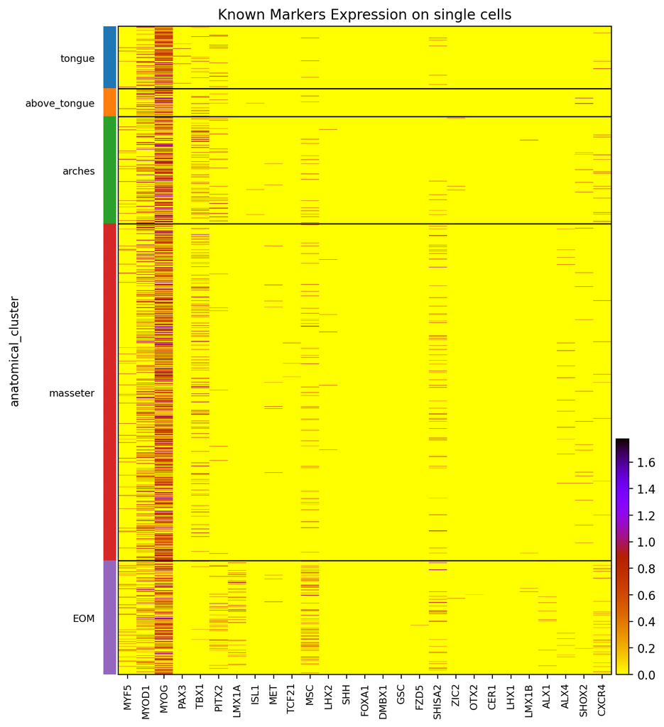

```python
### Log-normalized counts ###

markers=["MYF5", "MRF4", "MYOD1", "MYOG","PAX3", "TBX1", "PITX2", "LMX1A", "ISL1", "MET", "TCF21", "MSC", "LHX2", "SHH", "FOXA1", "DMBX1",  "GSC", "FZD5",  "SHISA2", "ZIC2",  "OTX2","CER1","LHX1", "LMX1B", "RIPPLY", "ALX1",  "ALX4", "SHOX2",  "CXCR4", "SDF1"]


# Check which genes are in adata
present_markers = [g for g in markers if g in adata.var_names]
absent_markers = [g for g in markers if g not in adata.var_names]

# Order for plotting (top to bottom of heatmap)
adata_muscle.obs["anatomical_cluster"] = adata_muscle.obs["anatomical_cluster"].cat.reorder_categories(
    [ "tongue", "above_tongue", "arches", "masseter", "EOM"],
    ordered=True
)

heatmap=sc.pl.heatmap(
    adata=adata_muscle,
    use_raw = False,
    groupby="anatomical_cluster",
    var_names=present_markers,
    cmap="gnuplot_r",
    figsize=(8,10),
    show=False
)

heatmap["heatmap_ax"].set_title("Known Markers Expression on single cells")
plt.show()
```

```python
print(f"{absent_markers} are not in the adata object")
```

```
['MRF4', 'RIPPLY', 'SDF1'] are not in the adata object
```

# Transcription Factors Enrichment Analysis

ULM incorporates weights of TF-gene (i.e. source-target) interactions.

The scores from decoupler.mt.ulm() should be interpreted such that larger magnitudes indicate greater significance, while the sign reflects whether the features in the set are overrepresented (positive) or underrepresented (negative) compared to the background.

Recall: the enrichment analysis using Univariate Linear Model (ulm) fits a linear predictor to the genes expression profile of each sample using as predictors the interaction weights of the genes targets of TFs. Then it applies a regression t-test to check whether the fitted line is good. In other words, if the TF whose targets approximate the gene expression profile is active. The t value is the Enrichment Score (ES). Positive ES means enrichment of TF, depletion otherwise.

https://decoupler.readthedocs.io/en/latest/notebooks/scell/rna_sc.html

### TF Databases Loading

```python
# Databases Loading
dorothea = dc.op.dorothea(levels=['A', 'B', 'C'], organism="human")
net_dorothea = dorothea[["source","target", "weight"]]

collectri = dc.op.collectri(organism="human")
net_collectri=collectri[["source", "target", "weight"]]

db_1 = collectri['source'].to_list()
db_2 = dorothea['source'].to_list()
db = db_1 + db_2
TF_genes = list(set(db))
```

### Genes Filtering

To reduce the False Positive rates.

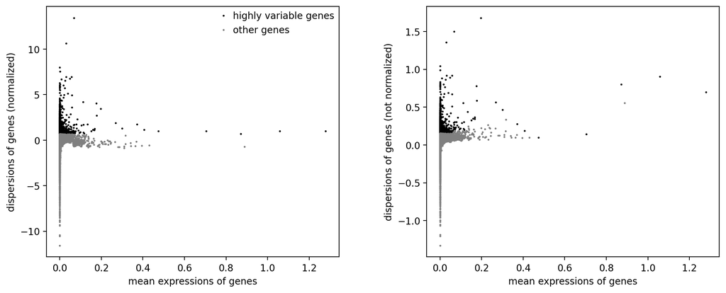

```
AnnData object with n_obs × n_vars = 2195 × 2000
    obs: 'id', 'n_genes_by_counts', 'log1p_n_genes_by_counts', 'total_counts', 'log1p_total_counts', 'pct_counts_in_top_50_genes', 'pct_counts_in_top_100_genes', 'pct_counts_in_top_200_genes', 'pct_counts_in_top_500_genes', 'total_counts_mt', 'log1p_total_counts_mt', 'pct_counts_mt', 'clusters', 'ex…
    var: 'gene_ids', 'feature_types', 'genome', 'mt', 'n_cells_by_counts', 'mean_counts', 'log1p_mean_counts', 'pct_dropout_by_counts', 'total_counts', 'log1p_total_counts', 'highly_variable', 'means', 'dispersions', 'dispersions_norm'
    uns: 'clusters', 'hvg', 'log1p', 'neighbors', 'pca', 'anatomical_cluster_colors'
    obsm: 'X_pca'
    varm: 'PCs'
    layers: 'counts', 'log_norm'
    obsp: 'connectivities', 'distances'
```

```python
# Select highly variable genes only
sc.pl.highly_variable_genes(adata_muscle)

# subset the AnnData to only highly variable genes
adata_muscle_hvg = adata_muscle[:, adata_muscle.var['highly_variable']].copy()
adata_muscle_hvg
```

### Enrichment with univariate linear model

```python
## Enrichment score using ulm method ##

dc.mt.ulm(data=adata_muscle_hvg, net=net_dorothea, tmin=4)
scores_dorothea = dc.pp.get_obsm(adata_muscle_hvg, key="score_ulm")
adata_muscle_hvg.obsm["score_dorothea"] = adata_muscle_hvg.obsm["score_ulm"].copy()
adata_muscle_hvg.obsm["padj_ulm_dorothea"] = adata_muscle_hvg.obsm["padj_ulm"].copy()

# Optional: delete the temporary 'score_ulm' key
del adata_muscle_hvg.obsm["score_ulm"]
del adata_muscle_hvg.obsm["padj_ulm"]

# Run second analysis (overwrites 'score_ulm')*
dc.mt.ulm(data=adata_muscle_hvg, net=net_collectri, tmin=4)
scores_collectri = dc.pp.get_obsm(adata_muscle_hvg, key="score_ulm")
adata_muscle_hvg.obsm["score_collectri"] = adata_muscle_hvg.obsm["score_ulm"].copy()
adata_muscle_hvg.obsm["padj_ulm_collectri"] = adata_muscle_hvg.obsm["padj_ulm"].copy()
```

### Results processing: select TF significantly enriched in more than 1/4 of cells

```python
########################################################
### Select some TFS ###
## Select only significant enrichment scores ##
########################################################


#### Parameters ####

# Significance threshold
alpha = 0.05
# Ratio of cells from an anatomical cluster in which the TF must be significant to kept
ratio = 1/4 #e.g. if 1/2, it means we keep only TFs that are significant in at least half of cells of a given anatomical cluster

######################



padj_df_dorothea = adata_muscle_hvg.obsm["padj_ulm_dorothea"]
padj_df_collectri = adata_muscle_hvg.obsm["padj_ulm_collectri"]

# Convert padj_df to long format
padj_df_dorothea["id"]=padj_df_dorothea.index
padj_df_dorothea_long=pd.melt(padj_df_dorothea, id_vars=["id"], var_name="TF", value_name="padj")

padj_df_collectri["id"]=padj_df_collectri.index
padj_df_collectri_long=pd.melt(padj_df_collectri, id_vars=["id"], var_name="TF", value_name="padj")

# Add a column anatomical_cluster based on id column and its corresponding "anatomical_cluster" value in adata_muscle
cluster_map = adata_muscle_hvg.obs.set_index("id")["anatomical_cluster"]
padj_df_dorothea_long["anatomical_cluster"] = padj_df_dorothea_long["id"].map(cluster_map)
padj_df_collectri_long["anatomical_cluster"] = padj_df_collectri_long["id"].map(cluster_map)

# Flag significant values
padj_df_dorothea_long["significant"] = padj_df_dorothea_long["padj"] <= alpha
padj_df_collectri_long["significant"] = padj_df_collectri_long["padj"] <= alpha

# Compute for each (anatomical cluster, TF) how many are significant
significance_counts_dorothea = (
    padj_df_dorothea_long[padj_df_dorothea_long["significant"]]
    .groupby(["anatomical_cluster", "TF"])
    .size()
    .rename("significant_count")
    .reset_index()
)
significance_counts_collectri = (
    padj_df_collectri_long[padj_df_collectri_long["significant"]]
    .groupby(["anatomical_cluster", "TF"])
    .size()
    .rename("significant_count")
    .reset_index()
)

# Compute anatomical cluster sizes (number of unique ids in each cluster)
cluster_sizes_dorothea = (
    padj_df_dorothea_long[["id", "anatomical_cluster"]]
    .drop_duplicates()
    .groupby("anatomical_cluster")
    .size()
    .rename("cluster_size")
    .reset_index()
)
cluster_sizes_collectri = (
    padj_df_collectri_long[["id", "anatomical_cluster"]]
    .drop_duplicates()
    .groupby("anatomical_cluster")
    .size()
    .rename("cluster_size")
    .reset_index()
)

# Add the cluster size info to significance counts
significance_counts_dorothea = significance_counts_dorothea.merge(cluster_sizes_dorothea, on="anatomical_cluster")
significance_counts_collectri = significance_counts_collectri.merge(cluster_sizes_collectri, on="anatomical_cluster")

# Keep only TFs where significant_count >= cluster_size * ratio i.e. TF significantly enriched/depleted in more than ratio of cells of the anatomical cluster
selected_TF_df_dorothea = significance_counts_dorothea[
    significance_counts_dorothea["significant_count"] >= significance_counts_dorothea["cluster_size"] * ratio
]
selected_TF_df_collectri = significance_counts_collectri[
    significance_counts_collectri["significant_count"] >= significance_counts_collectri["cluster_size"] * ratio
]

selected_TF_list_dorothea = selected_TF_df_dorothea["TF"].unique()
selected_TF_list_collectri = selected_TF_df_collectri["TF"].unique()
```

```
3456469897.py (40): The default of observed=False is deprecated and will be changed to True in a future version of pandas. Pass observed=False to retain current behavior or observed=True to adopt the future default and silence this warning.
3456469897.py (47): The default of observed=False is deprecated and will be changed to True in a future version of pandas. Pass observed=False to retain current behavior or observed=True to adopt the future default and silence this warning.
3456469897.py (57): The default of observed=False is deprecated and will be changed to True in a future version of pandas. Pass observed=False to retain current behavior or observed=True to adopt the future default and silence this warning.
3456469897.py (65): The default of observed=False is deprecated and will be changed to True in a future version of pandas. Pass observed=False to retain current behavior or observed=True to adopt the future default and silence this warning.
```

**Heatmap of Enrichment Scores for TFs being significantly enriched or depleted in a 1/4 of cells of each anatomical cluster**

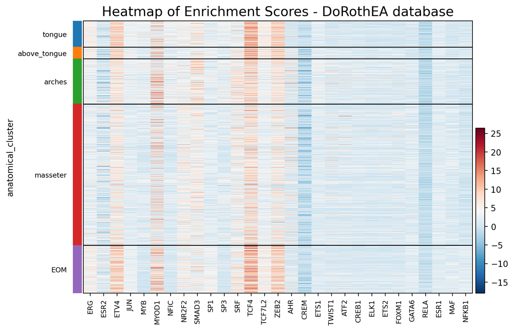

```python
# Heatmap of enrichment scores for TFs being significantly enriched or depleted in ratio of cells of each anatomical cluster
# Showing all scores
heatmap=sc.pl.heatmap(
    adata=scores_dorothea,
    groupby="anatomical_cluster",
    var_names=selected_TF_list_dorothea,
    cmap="RdBu_r",
    show=False
)

heatmap['heatmap_ax'].set_title('Heatmap of Enrichment Scores - DoRothEA database', fontdict={'fontsize': 16})
plt.show()
```

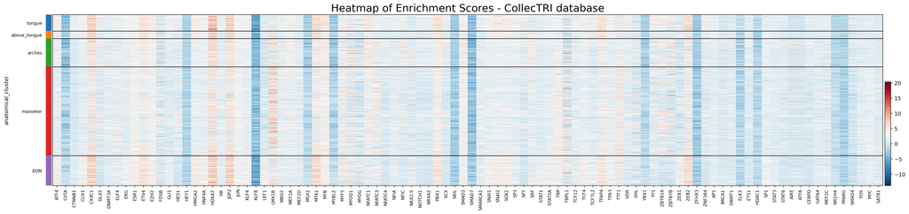

```python
heatmap=sc.pl.heatmap(
    adata=scores_collectri,
    groupby="anatomical_cluster",
    var_names=selected_TF_list_collectri,
    cmap="RdBu_r",
    show=False,
    show_gene_labels=True
)

heatmap['heatmap_ax'].set_title('Heatmap of Enrichment Scores - CollecTRI database', fontdict={'fontsize': 20})
plt.show()
```

**Heatmap showing significant pairs {muscle, enriched TF} only, when significance is found in more than 1/4 of cells for the given muscle**

```
3786786152.py (21): The default of observed=False is deprecated and will be changed to True in a future version of pandas. Pass observed=False to retain current behavior or observed=True to adopt the future default and silence this warning.
```

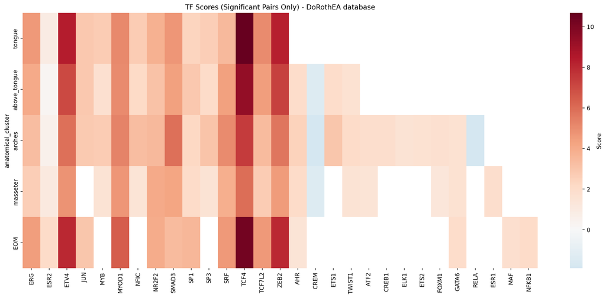

```python
############## Display only the {anatomical_cluster, TF} pairs for which significance in more than 1/4 of cells is found #########

# Create a mask for non-significant TF-cluster pairs
mask = pd.DataFrame(
    False,
    index=scores_dorothea.obs["anatomical_cluster"].cat.categories,
    columns=selected_TF_list_dorothea
)

# Fill the mask: True where TF is significant for the cluster
for _, row in selected_TF_df_dorothea.iterrows():
    mask.loc[row["anatomical_cluster"], row["TF"]] = True

# Convert mask to a boolean array matching the heatmap shape
cluster_order = scores_dorothea.obs["anatomical_cluster"].cat.categories
tf_order = selected_TF_list_dorothea
mask_array = mask.loc[cluster_order, tf_order].values

# Apply the mask to the data (set non-significant to NaN)
heatmap_data = scores_dorothea[:, selected_TF_list_dorothea].to_df()
heatmap_data = heatmap_data.groupby(scores_dorothea.obs["anatomical_cluster"]).mean()  # or median
heatmap_data[~mask_array] = np.nan  # Mask non-significant

plt.figure(figsize=(20, 8))
sns.heatmap(
    heatmap_data,
    cmap="RdBu_r",
    center=0,
    xticklabels=True,
    yticklabels=True,
    cbar_kws={"label": "Score"}
)
plt.title("TF Scores (Significant Pairs Only) - DoRothEA database")
plt.show()
```

```
3690128183.py (21): The default of observed=False is deprecated and will be changed to True in a future version of pandas. Pass observed=False to retain current behavior or observed=True to adopt the future default and silence this warning.
```

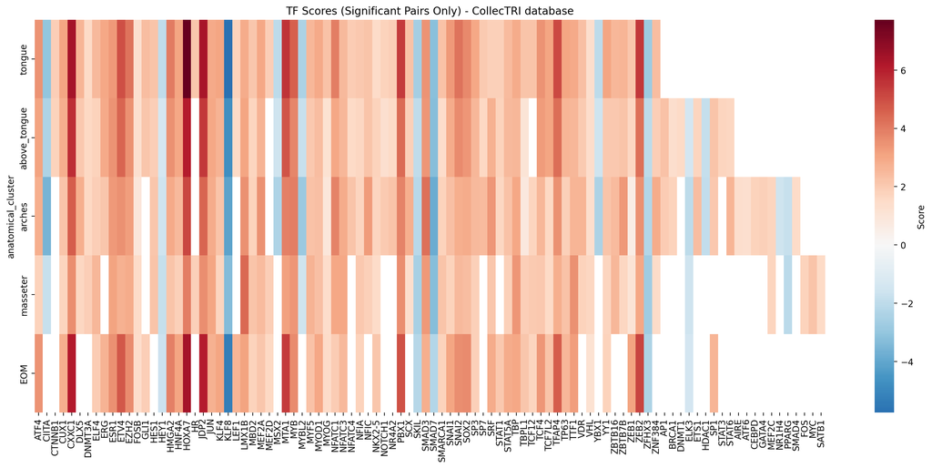

```python
############## Display only the {anatomical_cluster, TF} pairs for which significance in more than 1/4 of cells is found #########

# Create a mask for non-significant TF-cluster pairs
mask = pd.DataFrame(
    False,
    index=scores_collectri.obs["anatomical_cluster"].cat.categories,
    columns=selected_TF_list_collectri
)

# Fill the mask: True where TF is significant for the cluster
for _, row in selected_TF_df_collectri.iterrows():
    mask.loc[row["anatomical_cluster"], row["TF"]] = True

# Convert mask to a boolean array matching the heatmap shape
cluster_order = scores_collectri.obs["anatomical_cluster"].cat.categories
tf_order = selected_TF_list_collectri
mask_array = mask.loc[cluster_order, tf_order].values

# Apply the mask to the data (set non-significant to NaN)
heatmap_data = scores_collectri[:, selected_TF_list_collectri].to_df()
heatmap_data = heatmap_data.groupby(scores_collectri.obs["anatomical_cluster"]).mean()  # or median
heatmap_data[~mask_array] = np.nan  # Mask non-significant

plt.figure(figsize=(20, 8))
sns.heatmap(
    heatmap_data,
    cmap="RdBu_r",
    center=0,
    xticklabels=True,
    yticklabels=True,
    cbar_kws={"label": "Score"}
)
plt.title("TF Scores (Significant Pairs Only) - CollecTRI database")
plt.show()
```

**Heatmap of Expression of those enriched TF (significant in more than 1/4 of cells)**

TF can be enriched but not detected as it is rather their target genes which should be expressed.

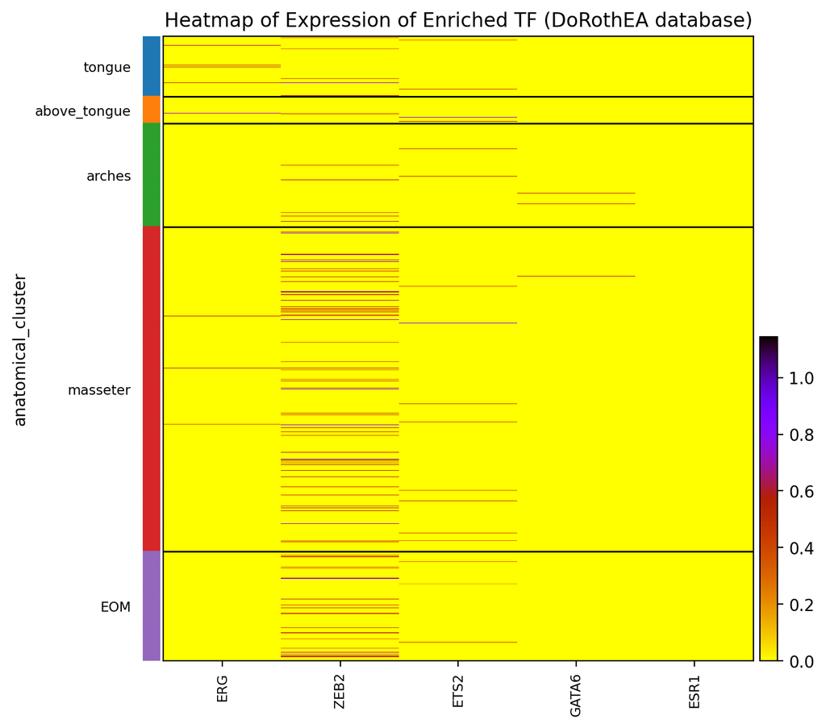

[output not shown]

```python
# Check how the reported enriched TF are expressed across clusters, on the heatmap
present_genes=[g for g in selected_TF_list_dorothea if g in adata_muscle_hvg.var_names]
absent_genes = [g for g in selected_TF_list_dorothea if g not in adata_muscle_hvg.var_names]

heatmap=sc.pl.heatmap(
    adata=adata_muscle_hvg,
    use_raw = False,
    groupby="anatomical_cluster",
    var_names=present_genes,
    cmap="gnuplot_r",
    figsize=(7,7),
    show=False
)

heatmap['heatmap_ax'].set_title('Heatmap of Expression of Enriched TF (DoRothEA database)')
plt.show()

print(f"Following TF aren't expressed in our data: {absent_genes}. \nBut their target genes are.")
```

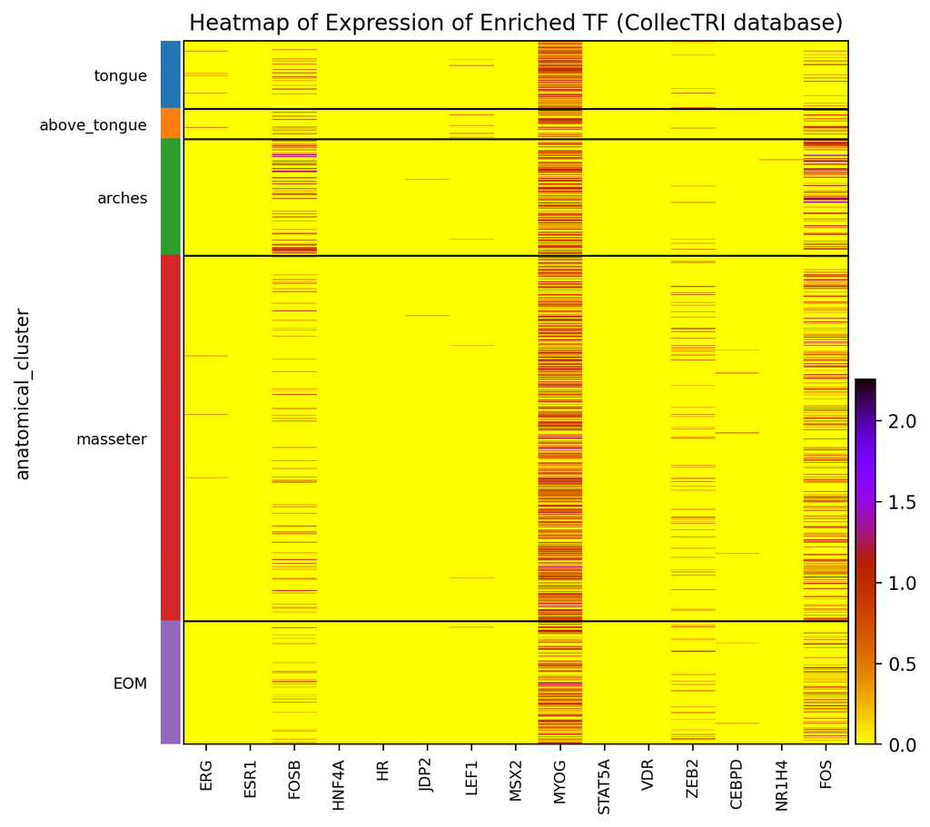

[output not shown]

```python
# Check how the reported enriched TF are expressed across clusters, on the heatmap
present_genes=[g for g in selected_TF_list_collectri if g in adata_muscle_hvg.var_names]
absent_genes = [g for g in selected_TF_list_collectri if g not in adata_muscle_hvg.var_names]

heatmap=sc.pl.heatmap(
    adata=adata_muscle_hvg,
    use_raw = False,
    groupby="anatomical_cluster",
    var_names=present_genes,
    cmap="gnuplot_r",
    figsize=(7,7),
    show=False
)

heatmap['heatmap_ax'].set_title('Heatmap of Expression of Enriched TF (CollecTRI database)')
plt.show()

print(f"Following TF aren't expressed in our data: {absent_genes}. \nBut their target genes are.")
```

### TF differentially expressed across muscles

```
WARNING: dendrogram data not found (using key=dendrogram_anatomical_cluster). Running `sc.tl.dendrogram` with default parameters. For fine tuning it is recommended to run `sc.tl.dendrogram` independently.
```

```
4221575664.py (12): The default of observed=False is deprecated and will be changed to True in a future version of pandas. Pass observed=False to retain current behavior or observed=True to adopt the future default and silence this warning.
4221575664.py (15): The default of observed=False is deprecated and will be changed to True in a future version of pandas. Pass observed=False to retain current behavior or observed=True to adopt the future default and silence this warning.
```

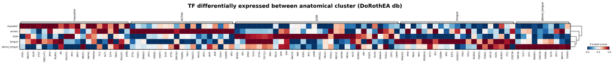

```python
##############################################################
###   Statistics to characterize features between groups   ###
##############################################################

df = dc.tl.rankby_group(adata=scores_dorothea, groupby="anatomical_cluster", reference="rest", method="t-test_overestim_var")
df = df[df["stat"] > 0]
df["anatomical_cluster"]=df["group"] # it created automatically a group variable, rename it to match our obs
df.drop(columns=["group"])

n_markers = 30
source_markers = (
    df.groupby("anatomical_cluster")
    .head(n_markers)
    .drop_duplicates("name")
    .groupby("anatomical_cluster")["name"]
    .apply(lambda x: list(x))
    .to_dict()
)

matrix_plot=sc.pl.matrixplot(
    adata=scores_dorothea,
    var_names=source_markers, #selected_TF_list,
    groupby="anatomical_cluster",
    dendrogram=True,
    standard_scale="var",
    colorbar_title="Z-scaled scores",
    cmap="RdBu_r",
    show=False
)
matrix_plot["mainplot_ax"].set_title("TF differentially expressed between anatomical cluster (DoRothEA db)", pad=60, fontdict={'fontsize': 20, 'fontweight': 'bold'})
plt.show()
```

```
325749365.py (8): The default of observed=False is deprecated and will be changed to True in a future version of pandas. Pass observed=False to retain current behavior or observed=True to adopt the future default and silence this warning.
325749365.py (11): The default of observed=False is deprecated and will be changed to True in a future version of pandas. Pass observed=False to retain current behavior or observed=True to adopt the future default and silence this warning.
```

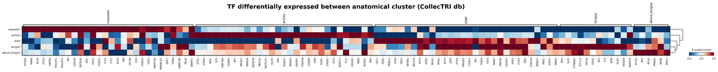

```python
df = dc.tl.rankby_group(adata=scores_collectri, groupby="anatomical_cluster", reference="rest", method="t-test_overestim_var")
df = df[df["stat"] > 0]
df["anatomical_cluster"]=df["group"] # it created automatically a group variable, rename it to match our obs
df.drop(columns=["group"])

n_markers = 30
source_markers = (
    df.groupby("anatomical_cluster")
    .head(n_markers)
    .drop_duplicates("name")
    .groupby("anatomical_cluster")["name"]
    .apply(lambda x: list(x))
    .to_dict()
)

matrix_plot=sc.pl.matrixplot(
    adata=scores_collectri,
    var_names=source_markers, #selected_TF_list,
    groupby="anatomical_cluster",
    dendrogram=True,
    standard_scale="var",
    colorbar_title="Z-scaled scores",
    cmap="RdBu_r",
    show=False
)
matrix_plot["mainplot_ax"].set_title("TF differentially expressed between anatomical cluster (CollecTRI db)", pad=60, fontdict={'fontsize': 20, 'fontweight': 'bold'})
plt.show()
```

# Differential Expression Analysis

```python
#### Aggregate several TF databases, to label in gold TF in DEA dotplots ####
collectri = dc.op.collectri(organism="human")
dorothea = dc.op.dorothea(levels=['A', 'B', 'C', 'D'], organism="human")

db_1 = collectri['source'].to_list()
db_2 = dorothea['source'].to_list()
db = db_1 + db_2
TF_genes = list(set(db))
```

DEA cannot be done with DESeq2 because data is too sparse, throwing error when DESeq2 tries to estimate size factors (because it relies on geometric means, and thus on log but log(0) is not defined).

Rather apply scanpy method to DEA, using t-test and/or wilcoxon.

## Cluster1 versus. rest (union of every cells not in cluster1)

```python
sc.tl.rank_genes_groups(adata_muscle_hvg, groupby="anatomical_cluster", method="t-test", use_raw=False, layer="log_norm") #it expects log normalized data, so I set use_raw to False
adata_muscle_hvg
```

```
AnnData object with n_obs × n_vars = 2195 × 2000
    obs: 'id', 'n_genes_by_counts', 'log1p_n_genes_by_counts', 'total_counts', 'log1p_total_counts', 'pct_counts_in_top_50_genes', 'pct_counts_in_top_100_genes', 'pct_counts_in_top_200_genes', 'pct_counts_in_top_500_genes', 'total_counts_mt', 'log1p_total_counts_mt', 'pct_counts_mt', 'clusters', 'ex…
    var: 'gene_ids', 'feature_types', 'genome', 'mt', 'n_cells_by_counts', 'mean_counts', 'log1p_mean_counts', 'pct_dropout_by_counts', 'total_counts', 'log1p_total_counts', 'highly_variable', 'means', 'dispersions', 'dispersions_norm'
    uns: 'clusters', 'hvg', 'log1p', 'neighbors', 'pca', 'anatomical_cluster_colors', 'dendrogram_anatomical_cluster', 'rank_genes_groups'
    obsm: 'X_pca', 'score_dorothea', 'padj_ulm_dorothea', 'score_ulm', 'padj_ulm', 'score_collectri', 'padj_ulm_collectri'
    varm: 'PCs'
    layers: 'counts', 'log_norm'
    obsp: 'connectivities', 'distances'
```

### 30 Top Markers

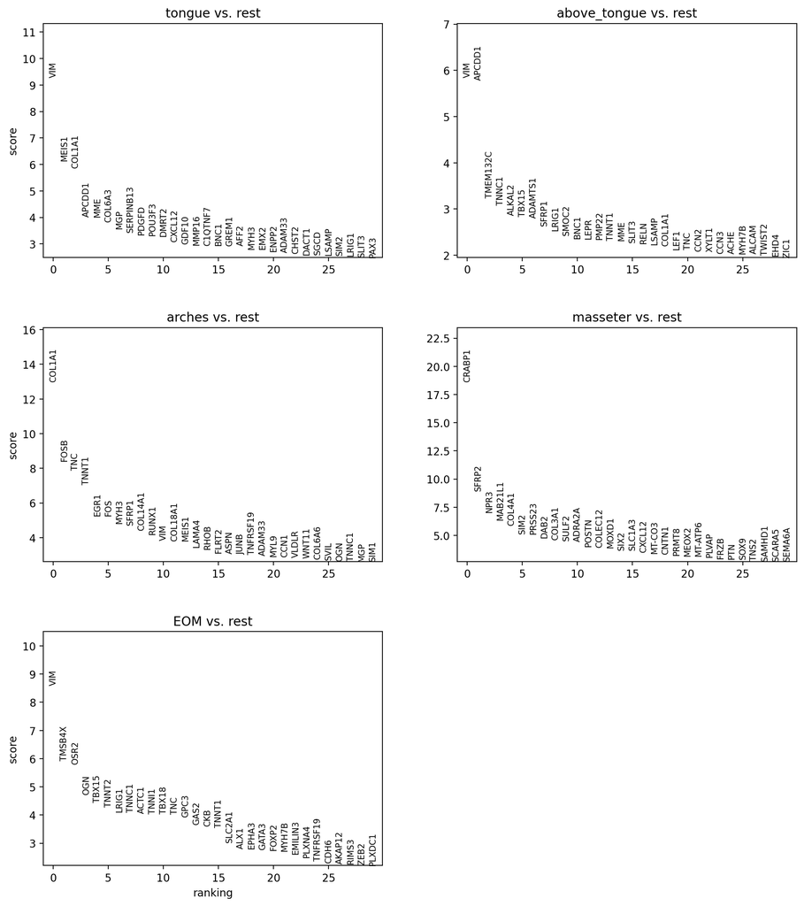

```python
sc.pl.rank_genes_groups(adata_muscle_hvg, n_genes=30, sharey=False, ncols=2)
```

### Dotplots

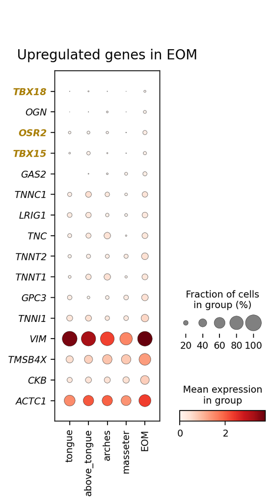

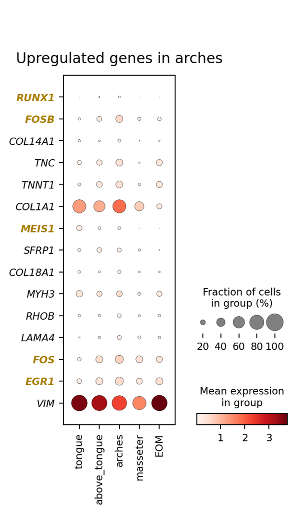

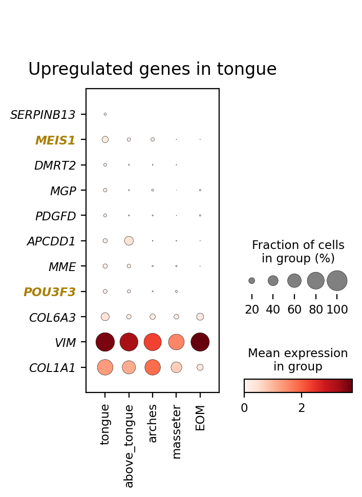

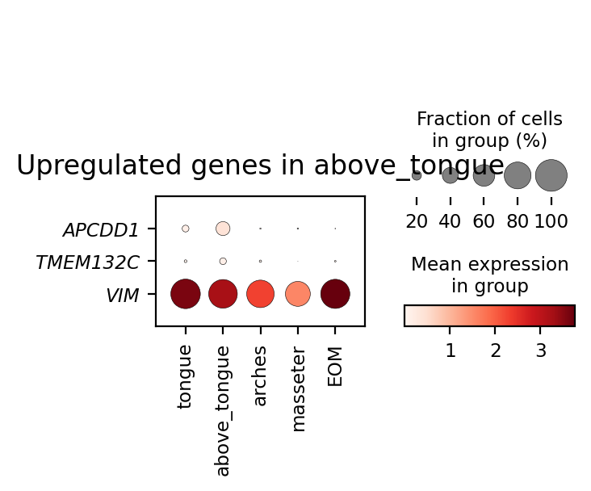

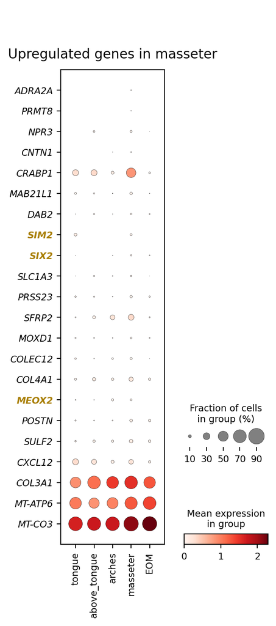

```python
anatomical_clusters = ["EOM", "arches", "tongue", "above_tongue", "masseter"]

for cluster in anatomical_clusters:
    ## Filter for only significant DEA genes ##
    df_muscle_only = sc.get.rank_genes_groups_df(adata_muscle_hvg, group=cluster)
    df_muscle_only = df_muscle_only[df_muscle_only['pvals_adj'] < 0.05]

    # Order to have higher logFC at the top and only positive logFC i.e. upregulated genes
    df_muscle_only = df_muscle_only.sort_values(by='logfoldchanges', ascending=False)
    df_muscle_only = df_muscle_only[df_muscle_only['logfoldchanges']>0]

    # Dotplot of upregulated genes
    dotplot = sc.pl.dotplot(adata_muscle_hvg, var_names=df_muscle_only['names'], groupby='anatomical_cluster', show=False, swap_axes=True)
    ax = dotplot["mainplot_ax"]
    ax.set_title(f"Upregulated genes in {cluster}", fontsize=12, pad=10)


    for label in ax.get_yticklabels():
        label.set_style("italic")
        gene = label.get_text()
        if gene in TF_genes:
            label.set_color("#A97F03")
            label.set_fontweight("bold")
        else:
            label.set_color("black")
            label.set_fontweight("normal")
    plt.show()
```

### Heatmaps

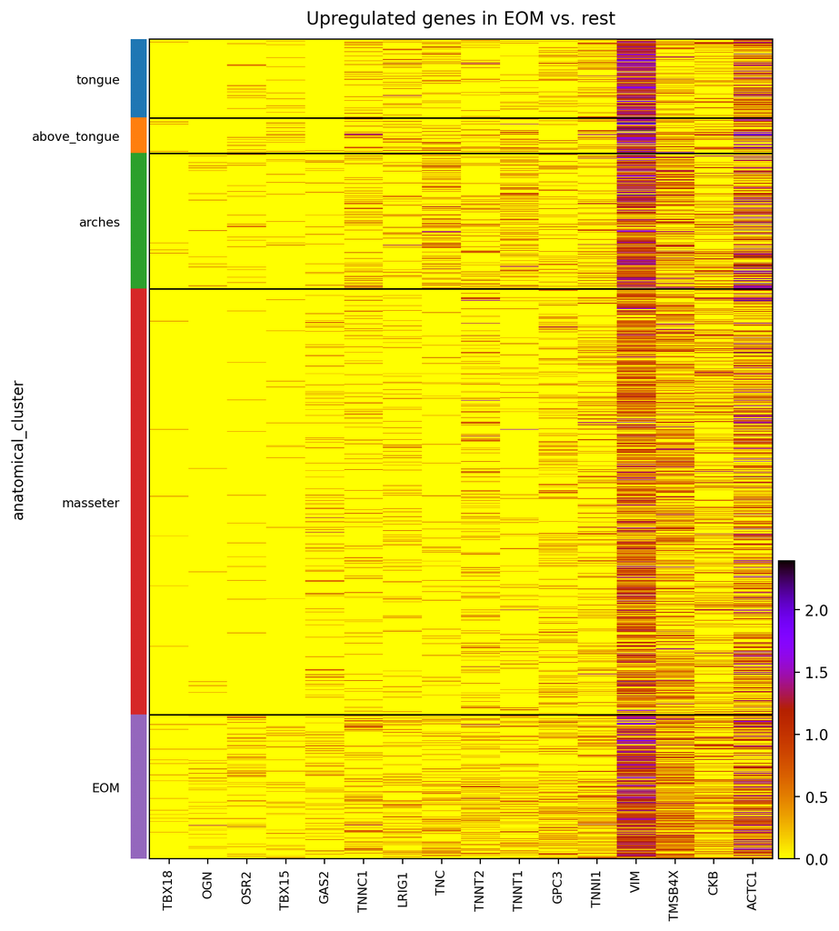

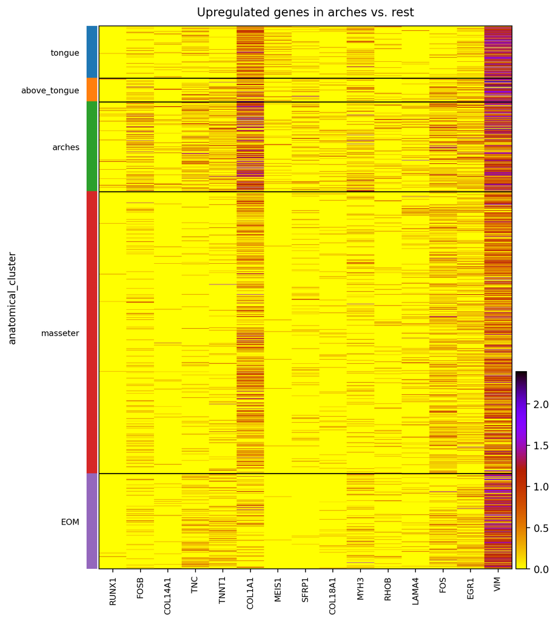

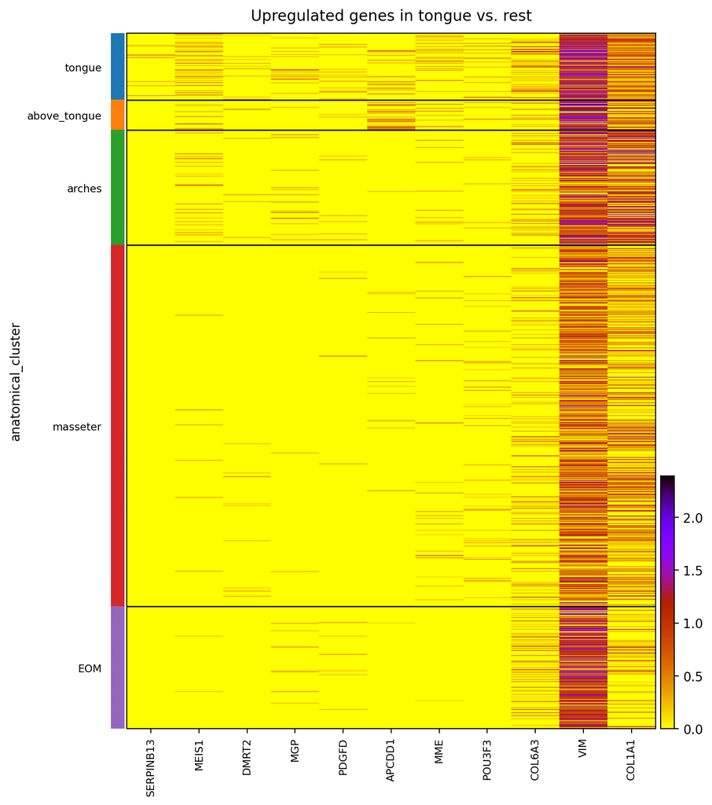

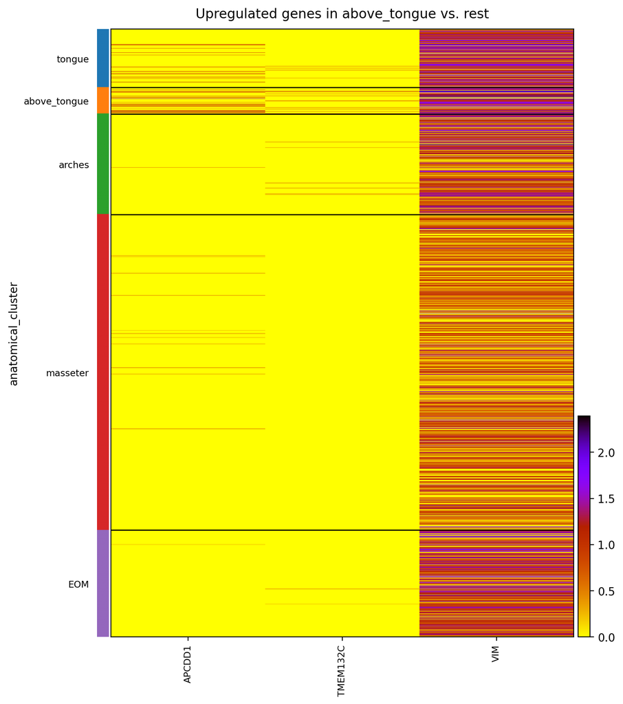

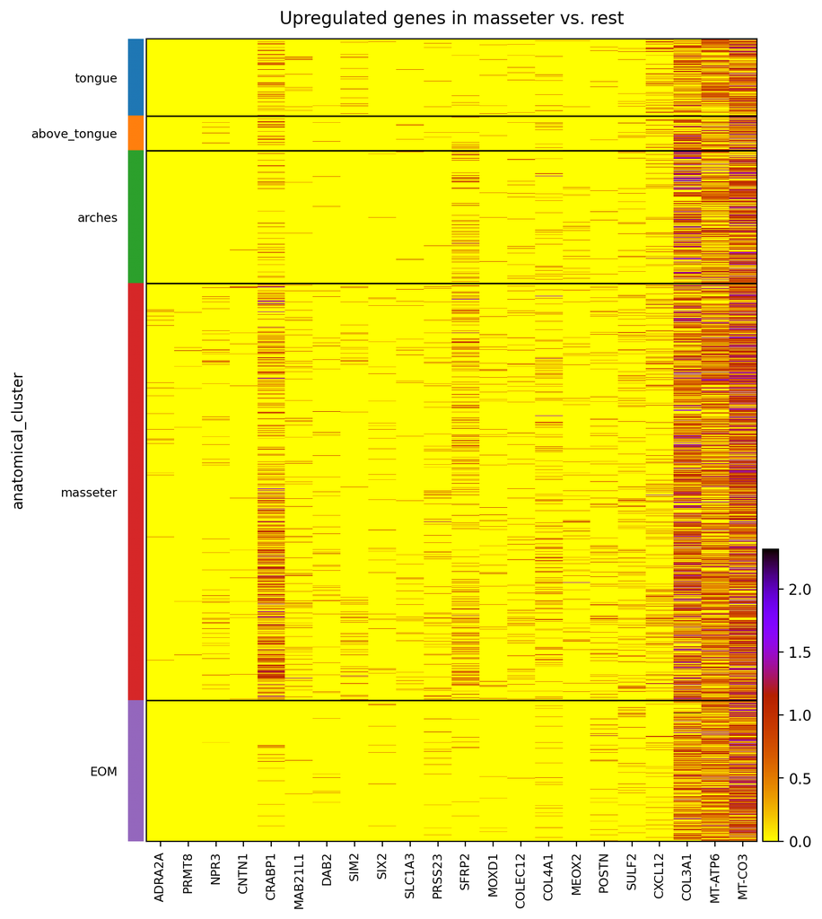

```python
for cluster in anatomical_clusters:
    ## Filter for only significant DEA genes ##
    df_muscle_only = sc.get.rank_genes_groups_df(adata_muscle_hvg, group=cluster)
    df_muscle_only = df_muscle_only[df_muscle_only['pvals_adj'] < 0.05]

    # Order to have higher logFC at the top and only positive logFC i.e. upregulated genes
    df_muscle_only = df_muscle_only.sort_values(by='logfoldchanges', ascending=False)
    df_muscle_only = df_muscle_only[df_muscle_only['logfoldchanges']>0]
    df_muscle_only = df_muscle_only[:50]

    # Dotplot of upregulated genes
    heatmap=sc.pl.heatmap(
        adata=adata_muscle_hvg,
        use_raw = False,
        groupby="anatomical_cluster",
        var_names=df_muscle_only['names'],
        cmap="gnuplot_r",
        figsize=(8,10),
        show=False,
        show_gene_labels=True
    )
    ax = heatmap["heatmap_ax"]
    ax.set_title(f"Upregulated genes in {cluster} vs. rest", fontsize=12, pad=10)


    for label in ax.get_yticklabels():
        label.set_style("italic")
        gene = label.get_text()
        if gene in TF_genes:
            label.set_color("#A97F03")
            label.set_fontweight("bold")
        else:
            label.set_color("black")
            label.set_fontweight("normal")
    plt.show()
```

## Pairwise Comparisons

```python
#### Perform Pairwise DEA ####

results = {}

for i in range(len(anatomical_clusters)):
    for j in range(i+1, len(anatomical_clusters)):
        group = anatomical_clusters[i]
        reference = anatomical_clusters[j]

        sc.tl.rank_genes_groups(
            adata_muscle_hvg,
            groupby='anatomical_cluster',
            groups=[group],
            reference=reference,
            method='t-test',  # "wilcoxon"
            n_genes=adata_muscle_hvg.shape[1],
            layer="log_norm",
            use_raw=False,
            copy=False,
            key_added=f"rank_{group}_vs_{reference}"  # store results under custom keys
        )

        # Collect results
        results[(group, reference)] = adata_muscle_hvg.uns[f"rank_{group}_vs_{reference}"]
```

```python
# Check which comparisons were performed
for x in results.keys():
  print(x)
```

```
('EOM', 'arches')
('EOM', 'tongue')
('EOM', 'above_tongue')
('EOM', 'masseter')
('arches', 'tongue')
('arches', 'above_tongue')
('arches', 'masseter')
('tongue', 'above_tongue')
('tongue', 'masseter')
('above_tongue', 'masseter')
```